# Assumptions

## Assumptions

- The $t$ procedures we have seen so far come with assumption of normally-distributed data
- but how much does that normality matter?
- Central Limit Theorem says that sampling distribution of sample mean is “approximately normal” if sample size is “large”.
- Hence same applies to difference of two sample means.
- How to use this in practice? Draw a picture and make a call about whether sample size large enough.

## Blue Jays attendances

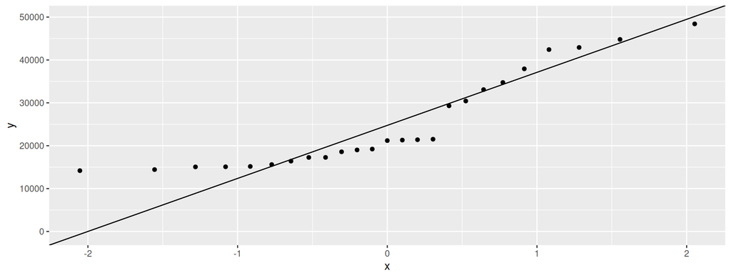

```r
ggplot(jays, aes(sample = attendance)) +
  stat_qq() + stat_qq_line()
```

## Comments

- Distribution of attendances somewhat skewed to the right (because of the short lower tail and the sort-of curve)
- Sample size $n = 25$ is reasonably large in Central Limit Theorem terms
- Use of $t$ *may* be OK here despite skewed shape.

## Learning to read

- Make normal quantile plots, one for each sample:

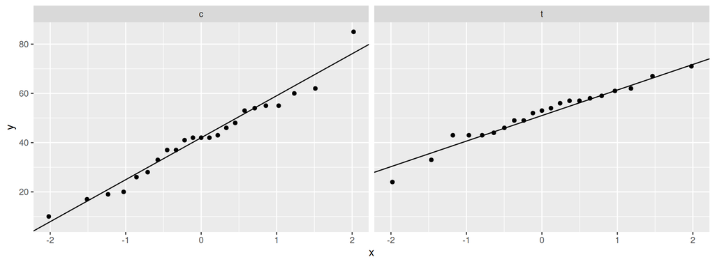

```r
ggplot(kids, aes(sample = score)) +
  stat_qq() + stat_qq_line() +
  facet_wrap(~ group)
```

## Comments

- with sample sizes over 20 in each group, these are easily normal enough to use a $t$-test.
- the (sampling distribution of the) difference between two sample means tends to have a more normal distribution than either sample mean individually, so that two-sample $t$ tends to be better than you’d guess.

## Pain relief

- With matched pairs, assumption is of normality of *differences*, so work those out first:

```r
pain %>% mutate(diff = druga - drugb) -> pain
pain
```

| subject | druga | drugb | diff |
| --- | --- | --- | --- |
| 1 | 2.0 | 3.5 | -1.5 |
| 2 | 3.6 | 5.7 | -2.1 |
| 3 | 2.6 | 2.9 | -0.3 |
| 4 | 2.6 | 2.4 | 0.2 |
| 5 | 7.3 | 9.9 | -2.6 |
| 6 | 3.4 | 3.3 | 0.1 |
| 7 | 14.9 | 16.7 | -1.8 |
| 8 | 6.6 | 6.0 | 0.6 |
| 9 | 2.3 | 3.8 | -1.5 |
| 10 | 2.0 | 4.0 | -2.0 |

[output cut: 2 more lines]

## Normality of differences

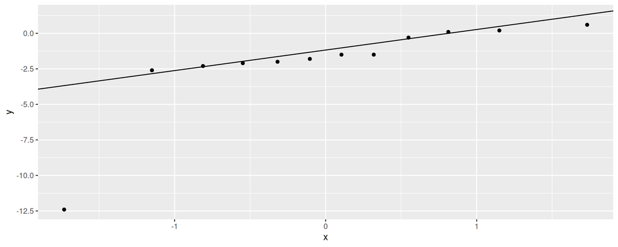

```r
ggplot(pain,aes(sample=diff)) + stat_qq() + stat_qq_line()
```

## Comments

- This is very non-normal (the low outlier)
- The sample size of $n = 12$ is not large
- We should have concerns about our matched pairs $t$-test.

## Doing things properly

- The right way to use a $t$ procedure:
  - draw a graph of our data (one of the standard graphs, or normal quantile plot)
  - use the graph to assess sufficient normality given the sample size
  - for a two-sample test, assess equality of spreads (boxplot easier for this)
  - if necessary, express our doubts about the $t$ procedure (for now), or do a better test (later).

## Looking ahead

- Looking at a normal quantile plot and assessing it with the sample size seems rather arbitrary. Can we do better? (Yes: using the bootstrap, later.)
- What to do if the $t$ procedure is not to be trusted? Use a different test (later):
  - one sample: sign test
  - two samples: Mood’s median test
  - matched pairs: sign test on differences.
- If you have heard about the signed rank or rank sum tests: they come with extra assumptions that are usually not satisfied if normality fails.